# Kaminda - Practical 2

###Words per Category

```r
tokenized.data %>%
  dplyr::group_by(medical_specialty) %>%
  dplyr::count(ngram, sort = TRUE) %>%
  dplyr::top_n(5)
```

| medical_specialty | ngram | n |
| --- | --- | --- |
| Orthopedic | chief complaint | 2 |
| Surgery | procedure endoscopic retrograde cholangiopancreatography brush cytology biopsy indication procedure patient history chronic abdominal pain ct evidence chronic pancreatitis recent upper endoscopy abnor… | 2 |
| Orthopedic | admission diagnoses fracture femoral neck history alzheimers dementia hypothyroidism discharge diagnoses fracture femoral neck history alzheimers dementia hypothyroidism status post hemiarthroplasty h… | 1 |
| Orthopedic | admission diagnoses neck pain upper extremity radiculopathy cervical spondylosis herniated nucleus pulposus stenosis discharge diagnoses neck pain upper extremity radiculopathy cervical spondylosis he… | 1 |
| Orthopedic | admission diagnosis bilateral spondylolysis pars defects spinal instability radiculopathy secondary diagnosis chronic pain syndrome principal procedure gill procedure interbody posterolateral degrees … | 1 |
| Orthopedic | admission diagnosis left hip fracture chief complaint diminished function secondary history pleasant gentleman ground level fall home brought abcd medical center evaluated dr brought orthopedic stay l… | 1 |
| Orthopedic | admission diagnosis painful knee status post total knee arthroplasty ago patient gradual onset worsening soreness pain knee ray poly worn significantly discharge diagnosis status post poly exchange kn… | 1 |
| Orthopedic | admission diagnosis tibial plateau fracture discharge diagnoses tibial plateau fracture medial meniscus tear procedures performed reduction internal fixation orif schatzker iii tibial plateau fracture… | 1 |
| Orthopedic | admitting diagnosis herniated nucleus pulposus primary operative procedure anterior cervical discectomy placement artificial disk replacement summary pleasant woman neck pain arm pain period time resp… | 1 |
| Orthopedic | admitting diagnosis posttraumatic av femoral head discharge diagnosis posttraumatic av femoral head secondary diagnoses prior hospitalization opioid hip surgery appendectomy gastroesophageal reflux di… | 1 |

[output cut: 990 more lines]

**5**

##Use of a Lemmatizer

#A general purpose lemmatizer may not work well for medical data. This is because medical data contains highly specialized terms that require accurately trained methods to be trained to accurately token terms. Some specific issues include:

#a. Medical data usually contains specialized terms, drugs names, and jargon. Therefore, a general purpose tool may not have the knowledge of these terms and may not be proficient in accurately identfying the lemmas.

#b. Medical terms typically come from different parts of speech such as nouns, verbs, and adjectives. Since the process of lemmatizing requires mapping to generate correct lemmas, general purpose lemmas (which have not been trained on medical data) may not process the variations in medical speech effectively.

```r
lemmatized.data <- tokenized.data %>% dplyr::mutate(lemma=textstem::lemmatize_words(ngram))
```

```r
lemma.freq <- lemmatized.data %>%
  dplyr::count(medical_specialty, lemma) %>%
  dplyr::group_by(medical_specialty) %>%
  dplyr::mutate(proportion = n / sum(n)) %>%
  tidyr::pivot_wider(names_from = medical_specialty, values_from = proportion) %>%
  tidyr::pivot_longer(`Surgery`:`Radiology`,
               names_to = "medical_specialty", values_to = "proportion")
```

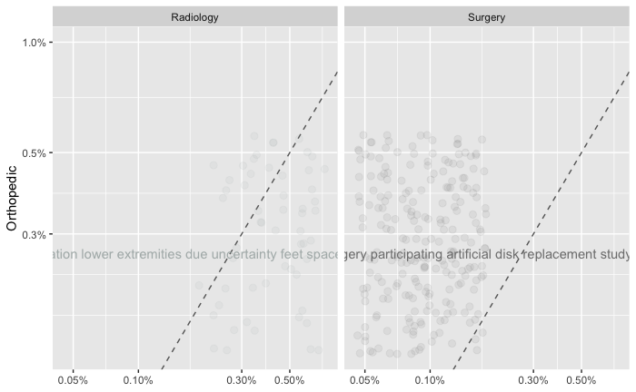

```r
ggplot2::ggplot(lemma.freq, ggplot2::aes(x=proportion,
                                         y=`Orthopedic`,
                                         color=abs(`Orthopedic` - proportion))) +
  ggplot2::geom_abline(color="gray40", lty=2) +
  ggplot2::geom_jitter(alpha=0.1, size=2.5, width=0.3, height=0.3) +
  ggplot2::geom_text(ggplot2::aes(label=lemma), check_overlap=TRUE, vjust=1.5) +
  ggplot2::scale_x_log10(labels=scales::percent_format()) +
  ggplot2::scale_y_log10(labels=scales::percent_format()) +
  ggplot2::scale_color_gradient(limits=c(0, 0.001), low="darkslategray4", high="gray75") +
  ggplot2::facet_wrap(~medical_specialty, ncol = 2) +
  ggplot2::theme(legend.position="none") +
  ggplot2:: labs(y="Orthopedic", x = NULL)
```

**6**

##Analyzing relative proportions

#This plot visualizes the same relative proportion of lemmas in each speciality. Based on these specialties, I would not expect to see the exact same relative proportions. There are some differences in the relationship between orthopaedics and radiology, and orthopaedics and surgery:

#Orthopaedics and surgery are more likely to have a high degree of common lemmas. Both specialties are based on standard anatomical terms.

#Orthopaedics and radiology are less likely to have a high degree of common lemmas. There is definitely overlap however, radiology may refer more to the technique of medical imaging. Therefore, many of the anatomical terms, diagnoses, and treatments related to orthopaedics may be missed.

**7**

##Direct comparison of surgery and radiology

```r
library(dplyr)
library(tidyr)
library(ggplot2)
library(textstem)
```

```r
lemmatized.data <- tokenized.data %>% dplyr::mutate(lemma=textstem::lemmatize_words(ngram))
```

```r
lemma.freq <- lemmatized.data %>%
  dplyr::count(medical_specialty, lemma) %>%
  dplyr::group_by(medical_specialty) %>%
  dplyr::mutate(proportion = n / sum(n)) %>%
  tidyr::pivot_wider(names_from = medical_specialty, values_from = proportion) %>%
  tidyr::pivot_longer(`Orthopedic`:`Radiology`,
               names_to = "medical_specialty", values_to = "proportion")
```

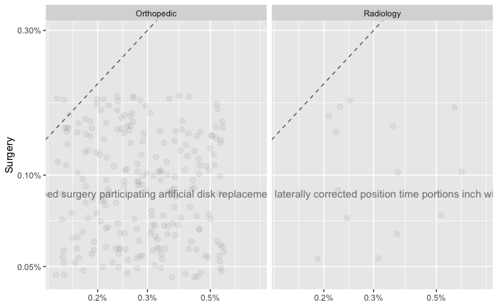

```r
ggplot2::ggplot(lemma.freq, ggplot2::aes(x=proportion,
                                         y=`Surgery`,
                                         color=abs(`Surgery` - proportion))) +
  ggplot2::geom_abline(color="gray40", lty=2) +
  ggplot2::geom_jitter(alpha=0.1, size=2.5, width=0.3, height=0.3) +
  ggplot2::geom_text(ggplot2::aes(label=lemma), check_overlap=TRUE, vjust=1.5) +
  ggplot2::scale_x_log10(labels=scales::percent_format()) +
  ggplot2::scale_y_log10(labels=scales::percent_format()) +
  ggplot2::scale_color_gradient(limits=c(0, 0.001), low="darkslategray4", high="gray75") +
  ggplot2::facet_wrap(~medical_specialty, ncol = 2) +
  ggplot2::theme(legend.position="none") +
  ggplot2:: labs(y="Surgery", x = NULL)
```

###TF-IDF Normailization